## ReneWind

Renewable energy sources play an increasingly important role in the global energy mix, as the effort to reduce the environmental impact of energy production increases.

Out of all the renewable energy alternatives, wind energy is one of the most developed technologies worldwide. The U.S Department of Energy has put together a guide to achieving operational efficiency using predictive maintenance practices.

Predictive maintenance uses sensor information and analysis methods to measure and predict degradation and future component capability. The idea behind predictive maintenance is that failure patterns are predictable and if component failure can be predicted accurately and the component is replaced before it fails, the costs of operation and maintenance will be much lower.

The sensors fitted across different machines involved in the process of energy generation collect data related to various environmental factors (temperature, humidity, wind speed, etc.) and additional features related to various parts of the wind turbine (gearbox, tower, blades, break, etc.).

## Objective

“ReneWind” is a company working on improving the machinery/processes involved in the production of wind energy using machine learning and has collected data of generator failure of wind turbines using sensors. They have shared a ciphered version of the data, as the data collected through sensors is confidential (the type of data collected varies with companies). Data has 40 predictors, 40000 observations in the training set and 10000 in the test set.

The objective is to build various classification models, tune them and find the best one that will help identify failures so that the generator could be repaired before failing/breaking and the overall maintenance cost of the generators can be brought down.

“1” in the target variables should be considered as “failure” and “0” will represent “No failure”.

The nature of predictions made by the classification model will translate as follows:

- True positives (TP) are failures correctly predicted by the model.
- False negatives (FN) are real failures in a wind turbine where there is no detection by model.
- False positives (FP) are detections in a wind turbine where there is no failure.

So, the maintenance cost associated with the model would be:

Maintenance cost = TP*(Repair cost) + FN*(Replacement cost) + FP*(Inspection cost) where,

- Replacement cost = $40,000
- Repair cost = $15,000
- Inspection cost = $5,000

Here the objective is to reduce the maintenance cost so, we want a metric that could reduce the maintenance cost.

- The minimum possible maintenance cost = Actual failures*(Repair cost) = (TP + FN)*(Repair cost)
- The maintenance cost associated with model = TP*(Repair cost) + FN*(Replacement cost) + FP*(Inspection cost)

So, we will try to maximize the ratio of minimum possible maintenance cost and the maintenance cost associated with the model.

The value of this ratio will lie between 0 and 1, the ratio will be 1 only when the maintenance cost associated with the model will be equal to the minimum possible maintenance cost.

### Data Description

- The data provided is a transformed version of original data which was collected using sensors.
- Train.csv - To be used for training and tuning of models.
- Test.csv - To be used only for testing the performance of the final best model.
- Both the datasets consist of 40 predictor variables and 1 target variable

### Importing libraries

```python
# To help with reading and manipulating data
import pandas as pd
import numpy as np

# To help with data visualization
%matplotlib inline
import matplotlib.pyplot as plt
import seaborn as sns

# To be used for missing value imputation
from sklearn.impute import SimpleImputer

# To help with model building
from sklearn.linear_model import LogisticRegression
from sklearn.tree import DecisionTreeClassifier
from sklearn.ensemble import (
    AdaBoostClassifier,
    GradientBoostingClassifier,
    RandomForestClassifier,
    BaggingClassifier,
)
from xgboost import XGBClassifier

# To get different metric scores, and split data
from sklearn import metrics
from sklearn.model_selection import train_test_split, StratifiedKFold, cross_val_score
from sklearn.metrics import (
    f1_score,
    accuracy_score,
    recall_score,
    precision_score,
    confusion_matrix,
    roc_auc_score,
    plot_confusion_matrix,
)

# To be used for data scaling and one hot encoding
from sklearn.preprocessing import StandardScaler, MinMaxScaler, OneHotEncoder

# To be used for tuning the model
from sklearn.model_selection import GridSearchCV, RandomizedSearchCV

# To be used for creating pipelines and personalizing them
from sklearn.pipeline import Pipeline
from sklearn.compose import ColumnTransformer

# To define maximum number of columns to be displayed in a dataframe
pd.set_option("display.max_columns", None)

# To supress scientific notations for a dataframe
pd.set_option("display.float_format", lambda x: "%.3f" % x)

# To supress warnings
import warnings

warnings.filterwarnings("ignore")

# This will help in making the Python code more structured automatically (good coding practice)
#%load_ext nb_black

# calculate accuracy measures and confusion matrix
from sklearn import metrics

from sklearn.metrics import recall_score

from imblearn.over_sampling import SMOTE
```

### Loading Data

```python
ren_train=pd.read_csv("Train.csv")
ren_test=pd.read_csv("Test.csv")
```

```python
ren_train.shape
```

```
(40000, 41)
```

```python
ren_train.sample(10)
```

|  | V1 | V2 | V3 | V4 | V5 | V6 | V7 | V8 | V9 | V10 | V11 | V12 | V13 | V14 | V15 | V16 | V17 | V18 | V19 | V20 | V21 | V22 | V23 | V24 | V25 | V26 | V27 | V28 | V29 | … |
| --- | --- | --- | --- | --- | --- | --- | --- | --- | --- | --- | --- | --- | --- | --- | --- | --- | --- | --- | --- | --- | --- | --- | --- | --- | --- | --- | --- | --- | --- | --- |
| 39369 | 0.951 | 5.122 | 0.171 | -1.217 | 2.795 | 0.220 | 1.837 | 1.591 | -3.729 | -1.723 | -0.251 | 5.513 | -4.640 | -3.807 | 2.517 | 0.526 | 2.829 | 1.626 | 1.187 | -6.078 | -0.708 | 1.623 | 3.348 | 7.958 | -1.553 | 3.884 | -4.643 | 0.035 | 1.991 | … |
| 39105 | -1.068 | -2.452 | -0.441 | -0.932 | -0.873 | -3.309 | 0.386 | 4.484 | -2.771 | 0.776 | -3.335 | 7.814 | 1.340 | 0.819 | -0.867 | 0.910 | 2.467 | 1.385 | 2.900 | 3.025 | -1.986 | 2.915 | 5.768 | 3.019 | 0.147 | -3.179 | -0.582 | 0.854 | -3.029 | … |
| 38994 | 1.234 | -0.446 | 1.536 | -1.833 | -0.014 | -0.693 | -0.037 | 0.190 | -0.518 | 0.510 | -2.619 | 1.738 | -0.001 | 0.003 | 0.084 | -1.884 | 0.699 | 1.735 | -0.145 | 0.254 | -1.833 | 1.459 | 0.407 | 0.749 | 1.558 | -0.250 | 1.614 | -0.280 | -2.203 | … |
| 6287 | -4.178 | 5.026 | -1.435 | 1.984 | 3.723 | 1.306 | 0.384 | -1.040 | -1.477 | -2.217 | 0.435 | 1.495 | -3.371 | -3.467 | -0.595 | 0.080 | 2.701 | 1.496 | 0.160 | -3.922 | 1.824 | -0.733 | 1.308 | 5.928 | -3.310 | 4.374 | -7.153 | 0.820 | 2.881 | … |
| 30956 | 1.324 | -0.637 | 7.247 | -8.705 | -0.257 | 3.763 | -0.393 | -7.477 | -1.840 | 4.850 | 1.817 | -0.603 | 1.842 | -1.652 | -0.399 | -5.087 | -10.370 | 3.156 | -0.800 | -8.080 | -3.275 | -1.249 | -9.573 | -3.230 | 1.506 | 4.178 | 9.807 | -3.990 | -0.161 | … |
| 1190 | 1.264 | -0.080 | -0.238 | -4.785 | 0.175 | -0.779 | -0.023 | 2.786 | -0.052 | -3.778 | -0.937 | 5.438 | 3.564 | -0.379 | -2.605 | 0.054 | 1.350 | 3.796 | -4.206 | 0.333 | -2.928 | 2.386 | 4.841 | -2.406 | 0.517 | 0.577 | -0.717 | -2.767 | 0.680 | … |
| 18896 | 0.575 | 4.397 | 5.901 | 1.589 | -1.165 | -1.904 | 3.653 | 1.397 | -3.752 | 0.743 | 2.347 | 6.333 | -3.632 | -3.861 | 7.047 | 4.036 | 0.186 | -6.498 | 8.152 | -2.228 | 1.921 | -4.319 | -6.509 | -0.103 | 0.489 | 3.266 | 0.743 | 0.759 | 3.161 | … |
| 16270 | -5.991 | -2.780 | 4.076 | 2.177 | -0.449 | -1.377 | -3.317 | -0.926 | -1.522 | 2.213 | -2.916 | 0.971 | 0.830 | -1.016 | -4.472 | -3.400 | -0.024 | 2.007 | 4.125 | 3.314 | -3.286 | -0.769 | -3.299 | 3.247 | -1.311 | -0.234 | -3.427 | 0.341 | 0.344 | … |
| 8198 | -2.390 | 2.111 | 1.977 | -2.178 | 3.278 | 0.133 | -3.495 | -3.083 | 2.129 | -2.732 | -5.039 | 0.415 | 5.407 | -1.633 | -10.017 | -8.271 | -0.186 | 7.653 | -5.020 | -2.133 | -7.822 | 3.547 | 3.056 | 2.889 | -1.503 | 6.628 | -4.160 | -3.708 | -2.486 | … |
| 23295 | -4.085 | 1.759 | 0.404 | 3.425 | 1.385 | -0.537 | 0.574 | 0.649 | -4.200 | 2.332 | 0.389 | 2.959 | -4.421 | -2.239 | 1.717 | 1.713 | 0.838 | -1.534 | 6.168 | -2.553 | 1.560 | -1.070 | -0.230 | 8.270 | -3.050 | 1.111 | -4.703 | 2.338 | 1.472 | … |

```python
ren_train.info()
```

```
<class 'pandas.core.frame.DataFrame'>
RangeIndex: 40000 entries, 0 to 39999
Data columns (total 41 columns):
 #   Column  Non-Null Count  Dtype
---  ------  --------------  -----
 0   V1      39954 non-null  float64
 1   V2      39961 non-null  float64
 2   V3      40000 non-null  float64
 3   V4      40000 non-null  float64
 4   V5      40000 non-null  float64
 5   V6      40000 non-null  float64
 6   V7      40000 non-null  float64
 7   V8      40000 non-null  float64
 8   V9      40000 non-null  float64
 9   V10     40000 non-null  float64
```

[output cut: 33 more lines]

```python
ren_train.isnull().sum()
```

```
V1        46
V2        39
V3         0
V4         0
V5         0
V6         0
V7         0
V8         0
V9         0
V10        0
V11        0
V12        0
V13        0
V14        0
V15        0
V16        0
V17        0
V18        0
V19        0
V20        0
V21        0
V22        0
V23        0
V24        0
V25        0
V26        0
V27        0
V28        0
V29        0
V30        0
V31        0
V32        0
V33        0
V34        0
V35        0
V36        0
V37        0
V38        0
V39        0
V40        0
Target     0
dtype: int64
```

- V1 has 46 and V2 has 39 missing values. as there isn't much description about the values, i'll use median imputer to replace these values by median.

```python
ren_train.describe().T
```

|  | count | mean | std | min | 25% | 50% | 75% | max |
| --- | --- | --- | --- | --- | --- | --- | --- | --- |
| V1 | 39954.000 | -0.288 | 3.449 | -13.502 | -2.751 | -0.774 | 1.837 | 17.437 |
| V2 | 39961.000 | 0.443 | 3.139 | -13.212 | -1.638 | 0.464 | 2.538 | 13.089 |
| V3 | 40000.000 | 2.506 | 3.406 | -11.469 | 0.203 | 2.265 | 4.585 | 18.366 |
| V4 | 40000.000 | -0.066 | 3.437 | -16.015 | -2.350 | -0.124 | 2.149 | 13.280 |
| V5 | 40000.000 | -0.045 | 2.107 | -8.613 | -1.507 | -0.097 | 1.346 | 9.403 |
| V6 | 40000.000 | -1.001 | 2.037 | -10.227 | -2.363 | -1.007 | 0.374 | 7.065 |
| V7 | 40000.000 | -0.893 | 1.757 | -8.206 | -2.037 | -0.935 | 0.207 | 8.006 |
| V8 | 40000.000 | -0.563 | 3.299 | -15.658 | -2.660 | -0.384 | 1.714 | 11.679 |
| V9 | 40000.000 | -0.008 | 2.162 | -8.596 | -1.494 | -0.052 | 1.426 | 8.507 |
| V10 | 40000.000 | -0.002 | 2.183 | -11.001 | -1.391 | 0.106 | 1.486 | 8.108 |
| V11 | 40000.000 | -1.918 | 3.116 | -14.832 | -3.941 | -1.942 | 0.089 | 13.852 |
| V12 | 40000.000 | 1.578 | 2.915 | -13.619 | -0.431 | 1.485 | 3.541 | 15.754 |
| V13 | 40000.000 | 1.591 | 2.865 | -13.830 | -0.209 | 1.654 | 3.476 | 15.420 |
| V14 | 40000.000 | -0.947 | 1.788 | -8.309 | -2.165 | -0.957 | 0.266 | 6.213 |
| V15 | 40000.000 | -2.436 | 3.341 | -17.202 | -4.451 | -2.399 | -0.382 | 12.875 |
| V16 | 40000.000 | -2.943 | 4.212 | -21.919 | -5.632 | -2.719 | -0.113 | 13.583 |
| V17 | 40000.000 | -0.143 | 3.344 | -17.634 | -2.227 | -0.028 | 2.072 | 17.405 |
| V18 | 40000.000 | 1.189 | 2.586 | -11.644 | -0.403 | 0.867 | 2.564 | 13.180 |
| V19 | 40000.000 | 1.181 | 3.395 | -13.492 | -1.051 | 1.278 | 3.497 | 16.059 |
| V20 | 40000.000 | 0.027 | 3.675 | -13.923 | -2.434 | 0.030 | 2.513 | 16.052 |
| V21 | 40000.000 | -3.621 | 3.557 | -19.436 | -5.921 | -3.559 | -1.284 | 13.840 |
| V22 | 40000.000 | 0.943 | 1.646 | -10.122 | -0.112 | 0.963 | 2.018 | 7.410 |
| V23 | 40000.000 | -0.388 | 4.052 | -16.188 | -3.119 | -0.275 | 2.438 | 15.080 |
| V24 | 40000.000 | 1.142 | 3.913 | -18.488 | -1.483 | 0.964 | 3.563 | 19.769 |
| V25 | 40000.000 | -0.003 | 2.025 | -8.228 | -1.373 | 0.021 | 1.400 | 8.223 |
| V26 | 40000.000 | 1.896 | 3.421 | -12.588 | -0.319 | 1.964 | 4.163 | 16.836 |
| V27 | 40000.000 | -0.617 | 4.392 | -14.905 | -3.692 | -0.910 | 2.201 | 21.595 |
| V28 | 40000.000 | -0.888 | 1.925 | -9.685 | -2.193 | -0.905 | 0.377 | 6.907 |
| V29 | 40000.000 | -1.005 | 2.676 | -12.579 | -2.799 | -1.206 | 0.604 | 11.852 |
| V30 | 40000.000 | -0.033 | 3.031 | -14.796 | -1.908 | 0.185 | 2.040 | 13.191 |
| V31 | 40000.000 | 0.506 | 3.483 | -19.377 | -1.799 | 0.491 | 2.778 | 17.255 |
| V32 | 40000.000 | 0.327 | 5.499 | -23.201 | -3.392 | 0.056 | 3.789 | 24.848 |
| V33 | 40000.000 | 0.057 | 3.574 | -17.454 | -2.238 | -0.050 | 2.256 | 16.692 |
| V34 | 40000.000 | -0.464 | 3.186 | -17.985 | -2.128 | -0.251 | 1.433 | 14.358 |
| V35 | 40000.000 | 2.235 | 2.924 | -15.350 | 0.332 | 2.110 | 4.045 | 16.805 |
| V36 | 40000.000 | 1.530 | 3.820 | -17.479 | -0.937 | 1.572 | 3.997 | 19.330 |
| V37 | 40000.000 | -0.000 | 1.778 | -7.640 | -1.266 | -0.133 | 1.161 | 7.803 |
| V38 | 40000.000 | -0.351 | 3.964 | -17.375 | -3.017 | -0.319 | 2.291 | 15.964 |
| V39 | 40000.000 | 0.900 | 1.751 | -7.136 | -0.262 | 0.921 | 2.069 | 7.998 |
| V40 | 40000.000 | -0.897 | 2.998 | -11.930 | -2.950 | -0.949 | 1.092 | 10.654 |
| Target | 40000.000 | 0.055 | 0.227 | 0.000 | 0.000 | 0.000 | 0.000 | 1.000 |

- Input variables are 40 from different sensors, ranging from negative to positive continuous values.

```python
# let's check for duplicate values in the data
ren_train.duplicated().sum()
```

```
0
```

```python
ren_train.nunique()
```

```
V1        39954
V2        39961
V3        40000
V4        40000
V5        40000
V6        40000
V7        40000
V8        40000
V9        40000
V10       40000
V11       40000
V12       40000
V13       40000
V14       40000
V15       39999
V16       40000
V17       40000
V18       40000
V19       40000
V20       40000
V21       40000
V22       40000
V23       40000
V24       40000
V25       40000
V26       40000
V27       40000
V28       40000
V29       40000
V30       40000
V31       40000
V32       40000
V33       40000
V34       40000
V35       40000
V36       40000
V37       40000
V38       40000
V39       40000
V40       40000
Target        2
dtype: int64
```

## Insights from Test Dataset

```python
ren_test.shape
```

```
(10000, 41)
```

```python
ren_test.info()
```

```
<class 'pandas.core.frame.DataFrame'>
RangeIndex: 10000 entries, 0 to 9999
Data columns (total 41 columns):
 #   Column  Non-Null Count  Dtype
---  ------  --------------  -----
 0   V1      9989 non-null   float64
 1   V2      9993 non-null   float64
 2   V3      10000 non-null  float64
 3   V4      10000 non-null  float64
 4   V5      10000 non-null  float64
 5   V6      10000 non-null  float64
 6   V7      10000 non-null  float64
 7   V8      10000 non-null  float64
 8   V9      10000 non-null  float64
 9   V10     10000 non-null  float64
```

[output cut: 33 more lines]

```python
ren_test.isnull().sum()
```

```
V1        11
V2         7
V3         0
V4         0
V5         0
V6         0
V7         0
V8         0
V9         0
V10        0
V11        0
V12        0
V13        0
V14        0
V15        0
V16        0
V17        0
V18        0
V19        0
V20        0
V21        0
V22        0
V23        0
V24        0
V25        0
V26        0
V27        0
V28        0
V29        0
V30        0
V31        0
V32        0
V33        0
V34        0
V35        0
V36        0
V37        0
V38        0
V39        0
V40        0
Target     0
dtype: int64
```

- In Test dataset, V1 has 11 and V2 has 7 missing values. as there isn't much description about the values, i'll use median imputer to replace these values by median as done in train dataset.

```python
ren_test.describe().T
```

|  | count | mean | std | min | 25% | 50% | 75% | max |
| --- | --- | --- | --- | --- | --- | --- | --- | --- |
| V1 | 9989.000 | -0.260 | 3.440 | -12.382 | -2.700 | -0.719 | 1.861 | 13.504 |
| V2 | 9993.000 | 0.417 | 3.160 | -11.625 | -1.701 | 0.456 | 2.526 | 14.079 |
| V3 | 10000.000 | 2.555 | 3.395 | -12.941 | 0.238 | 2.283 | 4.656 | 15.409 |
| V4 | 10000.000 | -0.054 | 3.462 | -14.682 | -2.371 | -0.169 | 2.144 | 12.896 |
| V5 | 10000.000 | -0.085 | 2.102 | -7.712 | -1.593 | -0.144 | 1.324 | 7.673 |
| V6 | 10000.000 | -1.014 | 2.039 | -8.949 | -2.377 | -1.015 | 0.354 | 6.273 |
| V7 | 10000.000 | -0.908 | 1.737 | -8.124 | -2.035 | -0.938 | 0.189 | 7.616 |
| V8 | 10000.000 | -0.599 | 3.343 | -12.710 | -2.684 | -0.387 | 1.698 | 10.792 |
| V9 | 10000.000 | 0.026 | 2.180 | -7.570 | -1.490 | -0.086 | 1.466 | 8.851 |
| V10 | 10000.000 | 0.019 | 2.169 | -8.291 | -1.362 | 0.150 | 1.537 | 7.691 |
| V11 | 10000.000 | -1.944 | 3.105 | -15.384 | -3.988 | -1.970 | 0.067 | 10.226 |
| V12 | 10000.000 | 1.551 | 2.906 | -10.650 | -0.465 | 1.455 | 3.516 | 12.984 |
| V13 | 10000.000 | 1.618 | 2.863 | -13.832 | -0.126 | 1.721 | 3.468 | 12.620 |
| V14 | 10000.000 | -0.941 | 1.816 | -7.814 | -2.160 | -0.948 | 0.262 | 6.180 |
| V15 | 10000.000 | -2.452 | 3.324 | -15.527 | -4.429 | -2.408 | -0.446 | 11.673 |
| V16 | 10000.000 | -3.016 | 4.276 | -20.986 | -5.682 | -2.794 | -0.120 | 13.976 |
| V17 | 10000.000 | -0.154 | 3.363 | -13.418 | -2.287 | -0.010 | 2.041 | 19.777 |
| V18 | 10000.000 | 1.180 | 2.566 | -12.214 | -0.401 | 0.877 | 2.556 | 13.642 |
| V19 | 10000.000 | 1.218 | 3.415 | -14.170 | -1.055 | 1.326 | 3.576 | 13.038 |
| V20 | 10000.000 | 0.078 | 3.704 | -13.720 | -2.417 | 0.079 | 2.529 | 14.497 |
| V21 | 10000.000 | -3.676 | 3.579 | -17.201 | -6.022 | -3.654 | -1.307 | 16.218 |
| V22 | 10000.000 | 0.950 | 1.622 | -8.832 | -0.083 | 0.976 | 2.005 | 7.505 |
| V23 | 10000.000 | -0.450 | 4.063 | -15.818 | -3.167 | -0.259 | 2.392 | 13.511 |
| V24 | 10000.000 | 1.093 | 3.915 | -12.749 | -1.577 | 0.918 | 3.537 | 17.806 |
| V25 | 10000.000 | 0.035 | 2.021 | -6.770 | -1.339 | 0.061 | 1.426 | 6.557 |
| V26 | 10000.000 | 1.878 | 3.422 | -11.414 | -0.265 | 1.973 | 4.170 | 17.528 |
| V27 | 10000.000 | -0.558 | 4.402 | -14.219 | -3.634 | -0.869 | 2.253 | 17.290 |
| V28 | 10000.000 | -0.885 | 1.928 | -7.933 | -2.169 | -0.934 | 0.396 | 7.416 |
| V29 | 10000.000 | -1.040 | 2.660 | -10.655 | -2.815 | -1.264 | 0.554 | 14.039 |
| V30 | 10000.000 | -0.067 | 3.039 | -14.054 | -1.950 | 0.138 | 2.002 | 10.315 |
| V31 | 10000.000 | 0.483 | 3.451 | -13.878 | -1.770 | 0.513 | 2.773 | 13.190 |
| V32 | 10000.000 | 0.253 | 5.503 | -20.520 | -3.459 | -0.013 | 3.762 | 26.539 |
| V33 | 10000.000 | 0.008 | 3.552 | -14.904 | -2.280 | -0.099 | 2.198 | 13.324 |
| V34 | 10000.000 | -0.423 | 3.168 | -17.135 | -2.066 | -0.203 | 1.472 | 14.581 |
| V35 | 10000.000 | 2.258 | 2.919 | -19.522 | 0.375 | 2.149 | 4.088 | 13.489 |
| V36 | 10000.000 | 1.550 | 3.794 | -14.912 | -0.892 | 1.620 | 4.061 | 17.116 |
| V37 | 10000.000 | -0.006 | 1.782 | -5.362 | -1.278 | -0.150 | 1.193 | 7.682 |
| V38 | 10000.000 | -0.373 | 3.998 | -15.335 | -3.004 | -0.362 | 2.335 | 13.726 |
| V39 | 10000.000 | 0.920 | 1.726 | -7.147 | -0.225 | 0.933 | 2.097 | 7.234 |
| V40 | 10000.000 | -0.937 | 3.011 | -10.779 | -2.993 | -0.986 | 1.085 | 10.392 |
| Target | 10000.000 | 0.055 | 0.227 | 0.000 | 0.000 | 0.000 | 0.000 | 1.000 |

- Input variables are 40 from different sensors, ranging from negative to positive continuous values.

```python
# let's check for duplicate values in the data
ren_test.duplicated().sum()
```

```
0
```

```python
ren_test.nunique()
```

```
V1         9989
V2         9993
V3        10000
V4        10000
V5        10000
V6        10000
V7        10000
V8        10000
V9        10000
V10       10000
V11       10000
V12       10000
V13       10000
V14       10000
V15       10000
V16       10000
V17       10000
V18       10000
V19       10000
V20       10000
V21       10000
V22       10000
V23       10000
V24       10000
V25       10000
V26       10000
V27       10000
V28       10000
V29       10000
V30       10000
V31       10000
V32       10000
V33       10000
V34       10000
V35       10000
V36       10000
V37       10000
V38       10000
V39       10000
V40       10000
Target        2
dtype: int64
```

## Exploratory Data Analysis and insights

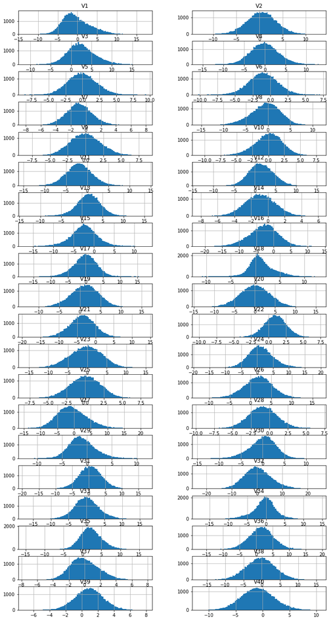

```python
columns1 = list(ren_train)[0:-1] # Excluding Outcome column which has only
ren_train[columns1].hist(stacked=False, bins=100, figsize=(12,30), layout=(25,2));
# Histogram of first 39 columns
```

- Mostly the variables have normal distributions.
- Distributions of V1, V18, V27, V37 are a bit right skewed

```python
ren_train.columns
```

```
Index(['V1', 'V2', 'V3', 'V4', 'V5', 'V6', 'V7', 'V8', 'V9', 'V10', 'V11',
       'V12', 'V13', 'V14', 'V15', 'V16', 'V17', 'V18', 'V19', 'V20', 'V21',
       'V22', 'V23', 'V24', 'V25', 'V26', 'V27', 'V28', 'V29', 'V30', 'V31',
       'V32', 'V33', 'V34', 'V35', 'V36', 'V37', 'V38', 'V39', 'V40',
       'Target'],
      dtype='object')
```

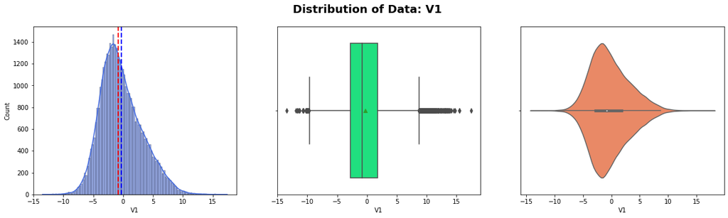

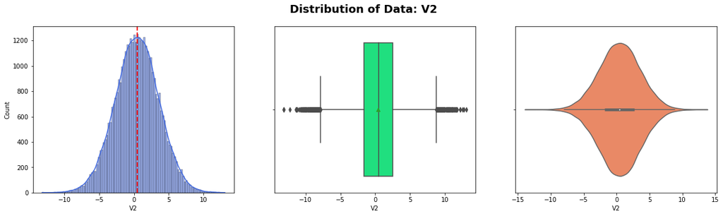

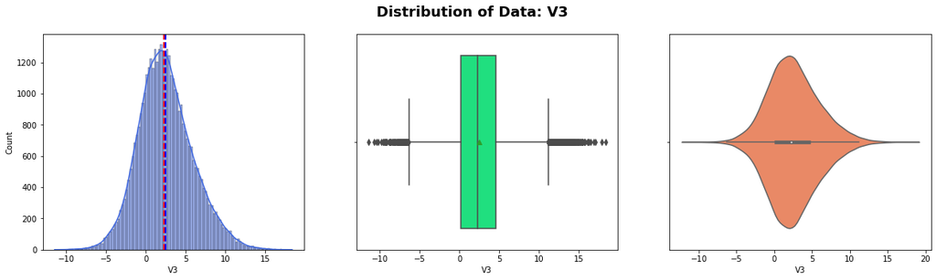

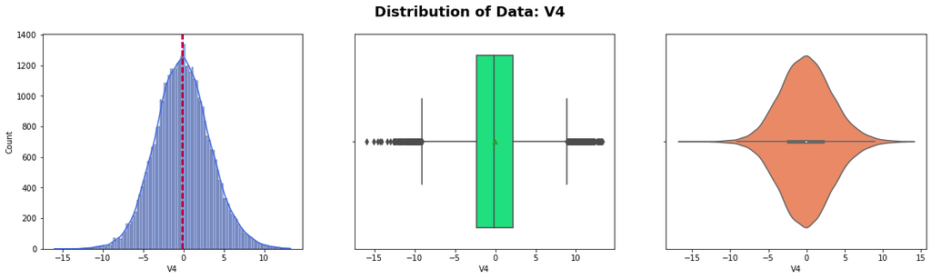

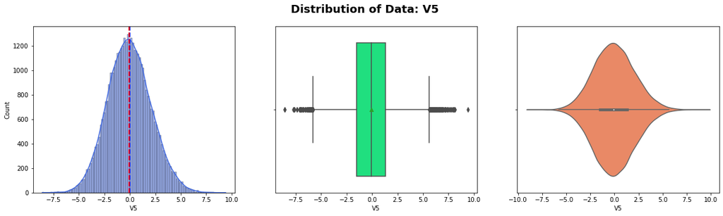

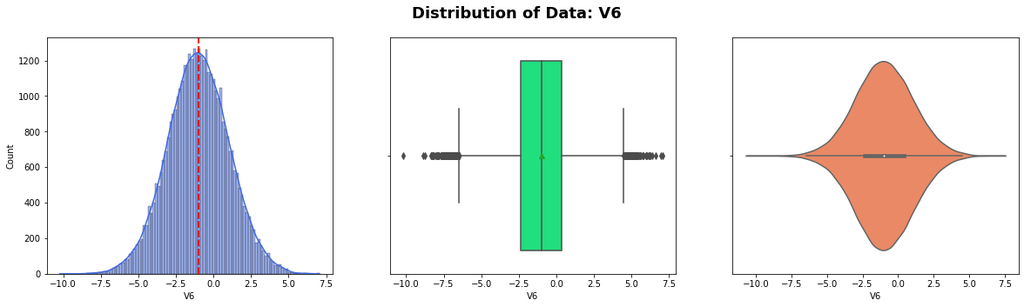

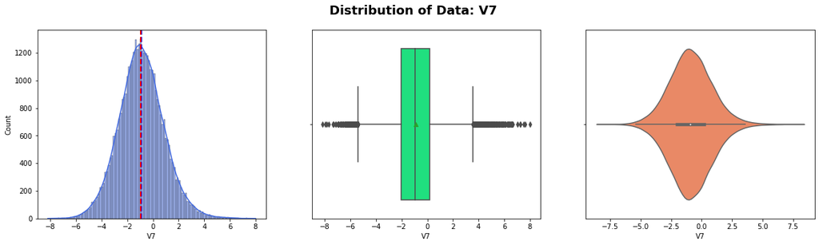

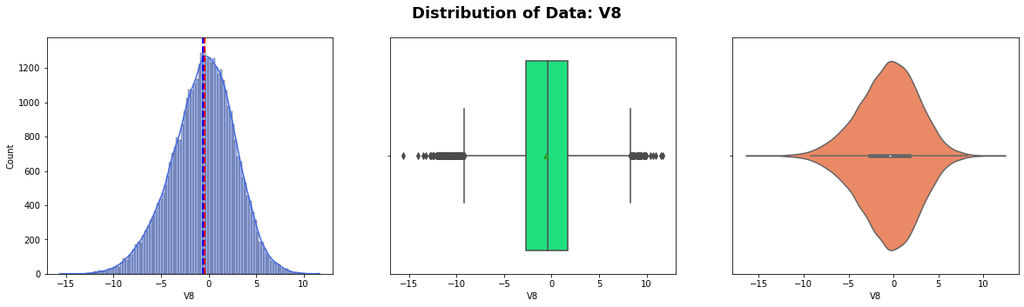

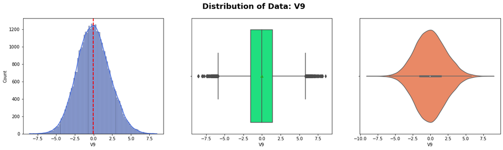

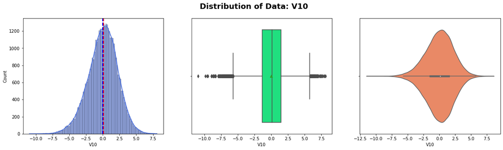

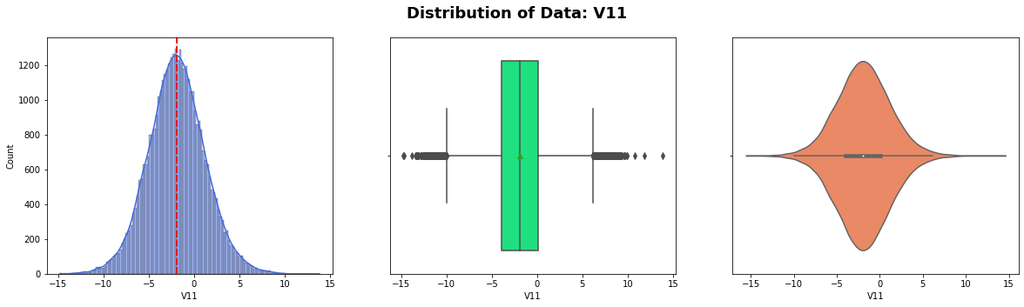

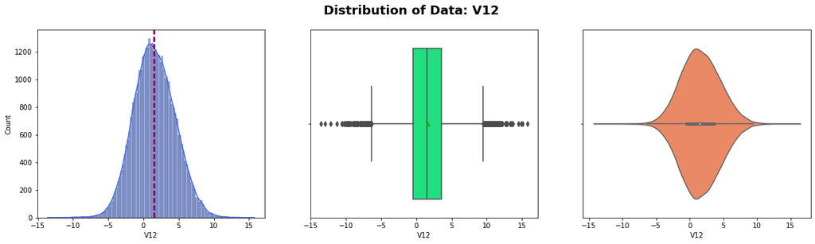

[28 more figures not shown]

```python
# The function to show distribution, box plot and violin plot for the non-categorical variables
# to understand the range, skewness, outliers, distribution of the attribute
def univariate_analysis_quantitative(df, attr):
    """
    Signature:
    univariate_analysis(
    df=None,
    attr=None
    )

    df: pd.DataFrame
    attr: List of attributes in the df dataframe

    Returns histogram, boxplot and violin plots for each of the attributes
    """
    for col in attr:
        fig, axes =plt.subplots(1,3,figsize=(20, 5))
        fig.suptitle("Distribution of Data: "+ col  , fontsize=18, fontweight='bold')
        sns.histplot(data=df, x=col, kde=True, ax=axes[0], color='royalblue')
        axes[0].axvline(df[col].mean(), color='b', linestyle='dashed',linewidth=2)
        axes[0].axvline(df[col].median(), color='r', linestyle='dashed', linewidth=2)
        sns.boxplot(data=df, x=col, showmeans=True, ax=axes[1], color='springgreen')
        sns.violinplot(data=df, x=col, ax=axes[2], color='coral')

univariate_analysis_quantitative(ren_train, ['V1', 'V2', 'V3', 'V4', 'V5', 'V6', 'V7', 'V8', 'V9', 'V10', 'V11',
       'V12', 'V13', 'V14', 'V15', 'V16', 'V17', 'V18', 'V19', 'V20', 'V21',
       'V22', 'V23', 'V24', 'V25', 'V26', 'V27', 'V28', 'V29', 'V30', 'V31',
       'V32', 'V33', 'V34', 'V35', 'V36', 'V37', 'V38', 'V39', 'V40'])
```

- Many variables have outliers but the distributions are normal and the information from sensors may be important, so i'll not treat the outliers

```python
# function to create labeled barplots


def labeled_barplot(data, feature, perc=False, n=None):
    """
    Barplot with percentage at the top

    data: dataframe
    feature: dataframe column
    perc: whether to display percentages instead of count (default is False)
    n: displays the top n category levels (default is None, i.e., display all levels)
    """

    total = len(data[feature])  # length of the column
    count = data[feature].nunique()
    if n is None:
        plt.figure(figsize=(count + 1, 5))
    else:
        plt.figure(figsize=(n + 1, 5))

    plt.xticks(rotation=90, fontsize=15)
    ax = sns.countplot(
        data=data,
        x=feature,
        palette="winter",
        order=data[feature].value_counts().index[:n].sort_values(),
        )

    for p in ax.patches:
        if perc == True:
            label = "{:.1f}%".format(
                100 * p.get_height() / total
            )  # percentage of each class of the category
        else:
            label = p.get_height()  # count of each level of the category

        x = p.get_x() + p.get_width() / 2  # width of the plot
        y = p.get_height()  # height of the plot

        ax.annotate(
            label,
            (x, y),
            ha="center",
            va="center",
            size=12,
            xytext=(0, 5),
            textcoords="offset points",
        )  # annotate the percentage

    plt.show()  # show the plot
```

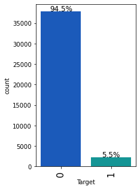

```python
fig = plt.figure()  # an empty figure with no axes
#fig, ax_lst = plt.subplots(2, 2)  # a figure with a 2x2 grid of Axes
#list_col=cat_columns
#for i in range(len(list_col)):
#    plt.title=list_col[i].upper()
labeled_barplot(ren_train, 'Target', perc=True)
```

- Majority of the generators in the dataset 94.5% do not have a faliure.
- Faliure has been found in only 5.5% of the generators.
- Data is heavily imbalanced, it would need some oversampling or undersampling.

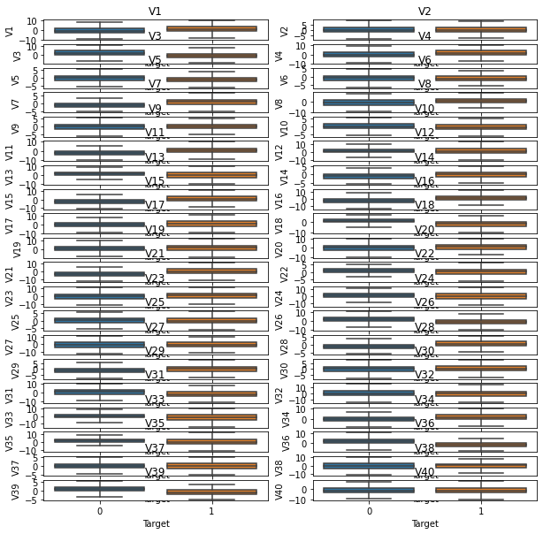

```python
cols = ren_train[
    [
        'V1', 'V2', 'V3', 'V4', 'V5', 'V6', 'V7', 'V8', 'V9', 'V10', 'V11',
       'V12', 'V13', 'V14', 'V15', 'V16', 'V17', 'V18', 'V19', 'V20', 'V21',
       'V22', 'V23', 'V24', 'V25', 'V26', 'V27', 'V28', 'V29', 'V30', 'V31',
       'V32', 'V33', 'V34', 'V35', 'V36', 'V37', 'V38', 'V39', 'V40'
    ]
].columns.tolist()
plt.figure(figsize=(10, 10))

for i, variable in enumerate(cols):
    plt.subplot(20, 2, i + 1)
    sns.boxplot(ren_train["Target"], ren_train[variable], showfliers=False)
    plt.tight_layout()
    plt.title(variable)
plt.show()
```

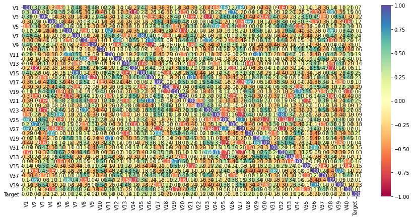

```python
plt.figure(figsize=(15, 7))
sns.heatmap(ren_train.corr(), annot=True, vmin=-1, vmax=1, fmt=".2f", cmap="Spectral")
plt.show()
```

- There are some variables showing correlation like V7 and V15, V9 and V16, V23 and V32.
- There are too many variables to read the correlation heatmap correctly.

## Data Pre-processing

```python
# Separating target variable and other variables in the training set
X_temp = ren_train.drop(columns="Target")
#X = pd.get_dummies(X)

y_temp = ren_train["Target"]
```

```python
# Separating target variable and other variables in the test set
X_test = ren_test.drop(columns="Target")
#X = pd.get_dummies(X)

y_test = ren_test["Target"]
```

```python
# Splitting temporary data into training, validation set:
# first we split data into 2 parts, say temporary and test


# then we split the temporary set into train and validation

X_train, X_val, y_train, y_val = train_test_split(
    X_temp, y_temp, test_size=0.25, random_state=1, stratify=y_temp
)
print(X_train.shape, X_val.shape, X_test.shape)
```

```
(30000, 40) (10000, 40) (10000, 40)
```

```python
print("Number of rows in train data =", X_train.shape[0])
print("Number of rows in validation data =", X_val.shape[0])
print("Number of rows in test data =", X_test.shape[0])
```

```
Number of rows in train data = 30000
Number of rows in validation data = 10000
Number of rows in test data = 10000
```

```python
# defining a list with names of columns that will be used for imputation
reqd_col_for_impute = [
    'V1', 'V2',
]
```

```python
imputer = SimpleImputer(strategy="median")
impute = imputer.fit(X_train)
```

```python
# Fit and transform the train data
X_train[reqd_col_for_impute] = imputer.fit_transform(X_train[reqd_col_for_impute])

# Transform the train data
X_val[reqd_col_for_impute] = imputer.transform(X_val[reqd_col_for_impute])

# Transform the test data
X_test[reqd_col_for_impute] = imputer.transform(X_test[reqd_col_for_impute])
```

```python
# Checking that no column has missing values in train, validation or test sets
print(X_train.isna().sum())
print("-" * 30)
print(X_val.isna().sum())
print("-" * 30)
print(X_test.isna().sum())
```

```
V1     0
V2     0
V3     0
V4     0
V5     0
V6     0
V7     0
V8     0
V9     0
V10    0
V11    0
V12    0
V13    0
V14    0
V15    0
V16    0
V17    0
V18    0
V19    0
V20    0
V21    0
V22    0
V23    0
V24    0
V25    0
V26    0
V27    0
V28    0
V29    0
V30    0
V31    0
V32    0
V33    0
V34    0
V35    0
V36    0
V37    0
V38    0
V39    0
V40    0
```

[output cut: 70 more lines]

```
V27    0
V28    0
V29    0
V30    0
V31    0
V32    0
V33    0
V34    0
V35    0
V36    0
V37    0
V38    0
V39    0
V40    0
dtype: int64
```

- All missing values have been treated in the train, validation and test data.

## Model evaluation criterion

### 3 types of cost are associated with the provided problem

1. Replacement cost - False Negatives - Predicting no failure, while there will be a failure
2. Inspection cost - False Positives - Predicting failure, while there is no failure
3. Repair cost - True Positives - Predicting failure correctly

### How to reduce the overall cost?

- We need to create a customized metric, that can help to bring down the overall cost.
- The cost associated with any model = TP 15000 + FP 5000 + FN * 40000
- And the minimum possible cost will be when, the model will be able to identify all failures, in that case, the cost will be (TP + FN) * 15000
- So, we will try to maximize Minimum cost/Cost associated with model

#### Let's create two functions to calculate different metrics and confusion matrix, so that we don't have to use the same code repeatedly for each model.

```python
# defining a function to compute different metrics to check performance of a classification model built using sklearn
def model_performance_classification_sklearn(model, predictors, target):
    """
    Function to compute different metrics to check classification model performance

    model: classifier
    predictors: independent variables
    target: dependent variable
    """

    TP = confusion_matrix(target, model.predict(predictors))[1, 1]
    FP = confusion_matrix(target, model.predict(predictors))[0, 1]
    FN = confusion_matrix(target, model.predict(predictors))[1, 0]
    Cost = TP * 15 + FP * 5 + FN * 40  # maintenance cost by using model
    Min_Cost = (TP + FN) * 15  # minimum possible maintenance cost = number of actual positives
    Percent = Min_Cost / Cost  # ratio of minimum possible maintenance cost and maintenance cost by model

    # predicting using the independent variables
    pred = model.predict(predictors)

    acc = accuracy_score(target, pred)  # to compute Accuracy
    recall = recall_score(target, pred)  # to compute Recall
    precision = precision_score(target, pred)  # to compute Precision
    f1 = f1_score(target, pred)  # to compute F1-score

    # creating a dataframe of metrics
    df_perf = pd.DataFrame(
        {
            "Accuracy": acc,
            "Recall": recall,
            "Precision": precision,
            "F1": f1,
            "Minimum_Vs_Model_cost": Percent,
        },
        index=[0],
    )

    return df_perf
```

```python
def confusion_matrix_sklearn(model, predictors, target):
    """
    To plot the confusion_matrix with percentages

    model: classifier
    predictors: independent variables
    target: dependent variable
    """
    y_pred = model.predict(predictors)
    cm = confusion_matrix(target, y_pred)
    labels = np.asarray(
        [
            ["{0:0.0f}".format(item) + "\n{0:.2%}".format(item / cm.flatten().sum())]
            for item in cm.flatten()
        ]
    ).reshape(2, 2)

    plt.figure(figsize=(6, 4))
    sns.heatmap(cm, annot=labels, fmt="")
    plt.ylabel("True label")
    plt.xlabel("Predicted label")
```

### Defining scorer to be used for hyperparameter tuning

- Every prediction of a classification model will be either a TP, FP, FN or TN.
- Till now at most of the places we wanted to reduce False negatives and hence we tried to maximize "Recall".
- To maximize Recall, we used Recall as a scorer in hyperparameter tuning.
- Here, we not only want to minimize false negatives but also false positives and we are also given the costs associated with each type of prediction.
- So, overall we want to reduce the maintenance cost which is: TP*(Repair cost) + FN*(Replacement cost) + FP*(Inspection cost)
- In simple language, we can say that we are assigning different weightage to the different types of predictions.
- Do we have any such metric which can help us minimize the maintenance cost? i.e., help us reduce FP and FN as per the weightage - We don't have any such inbuilt metric.
- In sklearn, we can define custom scorers also as per our need.
- For this classification problem, we need to reduce the maintenance cost, which can be reiterated as:
- Minimize (maintenance cost)
- Maximize (1/maintenance cost)
- Maximize (minimum possible maintenance cost/maintenance cost)
- Eventually, all 3 metrics will do the same work in the backend and the only difference will be in the scale of the values of the metric.
- The metric provided in the next cell is to maximize(minimum possible maintenance cost/maintenance cost)
- You can modify the metric as per convenience and use it further to tune the models.

```python
# defining metric to be used for optimization and with cross-validation
def Minimum_Vs_Model_cost(y_train, y_pred):
    """
    We want the model to optimize the maintenance cost and reduce it to the lowest possible value.
    The lowest possible maintenance cost will be achieved when each sample is predicted correctly.

    In such a scenario, the maintenance cost will be the total number of failures times the maintenance cost of replacing one generator,
    which is given by (TP + FN) * 40 (i.e., the actual positives*40).
    For any other scenario,
    the maintenance cost associated with the model will be given by (TP * 15 + FP * 5 + FN * 40).

    We will use the ratio of these two maintenance costs as the cost function for our model.
    The greater the ratio, the lower the associated maintenance cost and the better the model.
    """
    TP = confusion_matrix(y_train, y_pred)[1, 1]
    FP = confusion_matrix(y_train, y_pred)[0, 1]
    FN = confusion_matrix(y_train, y_pred)[1, 0]
    return ((TP + FN) * 15) / (TP * 15 + FP * 5 + FN * 40)


# A value of .80 here, will represent that the minimum maintenance cost is 80% of the maintenance cost associated with the model.
# Since minimum maintenance cost is constant for any data, when minimum cost will become 100% of maintenance cost associated with the model
# Model will have give the least possible maintenance cost.


# Type of scoring used to compare parameter combinations
scorer = metrics.make_scorer(Minimum_Vs_Model_cost, greater_is_better=True)

# Higher the values, the lower the maintenance cost
```

### Model Building with Original data

```python
models = []  # Empty list to store all the models

# Appending models into the list

models.append(("Logistic Regression", LogisticRegression(random_state=1)))
models.append(("Bagging", BaggingClassifier(random_state=1)))
models.append(("Random forest", RandomForestClassifier(random_state=1)))
models.append(("GBM", GradientBoostingClassifier(random_state=1)))
models.append(("Adaboost", AdaBoostClassifier(random_state=1)))
models.append(("Xgboost", XGBClassifier(random_state=1, eval_metric="logloss")))
models.append(("dtree", DecisionTreeClassifier(random_state=1)))

results = []  # Empty list to store all model's CV scores
names = []  # Empty list to store name of the models


# loop through all models to get the mean cross validated score
print("\n" "Cross-Validation Performance:" "\n")

for name, model in models:
    scoring = metrics.make_scorer(Minimum_Vs_Model_cost, greater_is_better=True)
    kfold = StratifiedKFold(
        n_splits=5, shuffle=True, random_state=1
    )  # Setting number of splits equal to 5
    cv_result = cross_val_score(
        estimator=model, X=X_train, y=y_train, scoring=scoring, cv=kfold
    )
    results.append(cv_result)
    names.append(name)
    print("{}: {}".format(name, cv_result.mean() * 100))

print("\n" "Training Performance:" "\n")

for name, model in models:
    model.fit(X_train, y_train)
    scores =Minimum_Vs_Model_cost(y_val, model.predict(X_val))
    #recall_score(y_train, model.predict(X_train)) * 100
    print("{}: {}".format(name, scores))
```

```
Cross-Validation Performance:

Logistic Regression: 52.948994378378856
Bagging: 68.86574469253958
Random forest: 71.52966747632996
GBM: 67.35879816374911
Adaboost: 59.88430481901255
Xgboost: 76.32838037155607
dtree: 65.12035300489133

Training Performance:

Logistic Regression: 0.5199619771863118
Bagging: 0.6889168765743073
Random forest: 0.7181619256017505
GBM: 0.6725409836065573
Adaboost: 0.5954281567489115
Xgboost: 0.7733270499528746
dtree: 0.6606280193236715
```

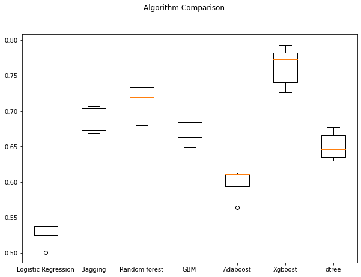

```python
# Plotting boxplots for CV scores of all models defined above
fig = plt.figure(figsize=(10, 7))

fig.suptitle("Algorithm Comparison")
ax = fig.add_subplot(111)

plt.boxplot(results)
ax.set_xticklabels(names)

plt.show()
```

### Oversampling train data using SMOTE

```python
# Synthetic Minority Over Sampling Technique
# sm = SMOTE(sampling_strategy=1, k_neighbors=5, random_state=1)
# X_train_over, y_train_over = sm.fit_resample(X_train, y_train)
```

```python
print("Before UpSampling, counts of label 'Yes': {}".format(sum(y_train == 1)))
print("Before UpSampling, counts of label 'No': {} \n".format(sum(y_train == 0)))

sm = SMOTE(
    sampling_strategy=1, k_neighbors=5, random_state=1
)  # Synthetic Minority Over Sampling Technique
X_train_over, y_train_over = sm.fit_resample(X_train, y_train)


print("After UpSampling, counts of label 'Yes': {}".format(sum(y_train_over == 1)))
print("After UpSampling, counts of label 'No': {} \n".format(sum(y_train_over == 0)))


print("After UpSampling, the shape of train_X: {}".format(X_train_over.shape))
print("After UpSampling, the shape of train_y: {} \n".format(y_train_over.shape))
```

```
Before UpSampling, counts of label 'Yes': 1640
Before UpSampling, counts of label 'No': 28360

After UpSampling, counts of label 'Yes': 28360
After UpSampling, counts of label 'No': 28360

After UpSampling, the shape of train_X: (56720, 40)
After UpSampling, the shape of train_y: (56720,)
```

### Models performance with oversampled data

```python
models_os = []  # Empty list to store all the models

# Appending models into the list

models_os.append(("Logistic Regression", LogisticRegression(random_state=1)))
models_os.append(("Bagging", BaggingClassifier(random_state=1)))
models_os.append(("Random forest", RandomForestClassifier(random_state=1)))
models_os.append(("GBM", GradientBoostingClassifier(random_state=1)))
models_os.append(("Adaboost", AdaBoostClassifier(random_state=1)))
models_os.append(("Xgboost", XGBClassifier(random_state=1, eval_metric="logloss")))
models_os.append(("dtree", DecisionTreeClassifier(random_state=1)))

results = []  # Empty list to store all model's CV scores
names = []  # Empty list to store name of the models


# loop through all models to get the mean cross validated score
print("\n" "Cross-Validation Performance:" "\n")

for name, model in models_os:
    scoring = metrics.make_scorer(Minimum_Vs_Model_cost, greater_is_better=True)
    kfold = StratifiedKFold(
        n_splits=5, shuffle=True, random_state=1
    )  # Setting number of splits equal to 5
    cv_result = cross_val_score(
        estimator=model, X=X_train_over, y=y_train_over, scoring=scoring, cv=kfold
    )
    results.append(cv_result)
    names.append(name)
    print("{}: {}".format(name, cv_result.mean() * 100))

print("\n" "Training Performance:" "\n")

for name, model in models_os:
    model.fit(X_train_over, y_train_over)
    scores =Minimum_Vs_Model_cost(y_val, model.predict(X_val))
    #recall_score(y_train, model.predict(X_train)) * 100
    print("{}: ".format(name))
    print(" {} ".format(scores))
```

```
Cross-Validation Performance:

Logistic Regression: 80.0088377103361
Bagging: 95.40942899036293
Random forest: 96.92752086101537
GBM: 86.76274431000867
Adaboost: 82.87444544309412
Xgboost: 97.25247518015713
dtree: 94.13857336531703

Training Performance:

Logistic Regression:
 0.5026033690658499
Bagging:
 0.7590194264569843
Random forest:
 0.8123762376237624
GBM:
 0.731935771632471
Adaboost:
 0.5629502572898799
Xgboost:
 0.813181367690783
dtree:
 0.6465721040189125
```

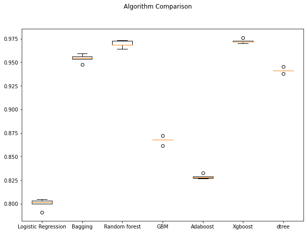

```python
# Plotting boxplots for CV scores of all models defined above
fig = plt.figure(figsize=(10, 7))

fig.suptitle("Algorithm Comparison")
ax = fig.add_subplot(111)

plt.boxplot(results)
ax.set_xticklabels(names)

plt.show()
```

### Model Building with Undersampled data

```python
from imblearn.under_sampling import RandomUnderSampler
```

```python
# Random undersampler for under sampling the data
rus = RandomUnderSampler(random_state=1, sampling_strategy=1)
X_train_un, y_train_un = rus.fit_resample(X_train, y_train)
```

```python
print("Before DownSampling, counts of label 'Yes': {}".format(sum(y_train == 1)))
print("Before DownSampling, counts of label 'No': {} \n".format(sum(y_train == 0)))

sm = SMOTE(
    sampling_strategy=1, k_neighbors=5, random_state=1
)  # Synthetic Minority Over Sampling Technique
X_train_over, y_train_over = sm.fit_resample(X_train, y_train)


print("After DownSampling, counts of label 'Yes': {}".format(sum(y_train_un == 1)))
print("After DownSampling, counts of label 'No': {} \n".format(sum(y_train_un == 0)))


print("After DownSampling, the shape of train_X: {}".format(X_train_un.shape))
print("After DownSampling, the shape of train_y: {} \n".format(y_train_un.shape))
```

```
Before DownSampling, counts of label 'Yes': 1640
Before DownSampling, counts of label 'No': 28360

After DownSampling, counts of label 'Yes': 1640
After DownSampling, counts of label 'No': 1640

After DownSampling, the shape of train_X: (3280, 40)
After DownSampling, the shape of train_y: (3280,)
```

```python
models_us = []  # Empty list to store all the models

# Appending models into the list

models_us.append(("Logistic Regression", LogisticRegression(random_state=1)))
models_us.append(("Bagging", BaggingClassifier(random_state=1)))
models_us.append(("Random forest", RandomForestClassifier(random_state=1)))
models_us.append(("GBM", GradientBoostingClassifier(random_state=1)))
models_us.append(("Adaboost", AdaBoostClassifier(random_state=1)))
models_us.append(("Xgboost", XGBClassifier(random_state=1, eval_metric="logloss")))
models_us.append(("dtree", DecisionTreeClassifier(random_state=1)))

results = []  # Empty list to store all model's CV scores
names = []  # Empty list to store name of the models


# loop through all models to get the mean cross validated score
print("\n" "Cross-Validation Performance:" "\n")

for name, model in models_us:
    scoring = metrics.make_scorer(Minimum_Vs_Model_cost, greater_is_better=True)
    kfold = StratifiedKFold(
        n_splits=5, shuffle=True, random_state=1
    )  # Setting number of splits equal to 5
    cv_result = cross_val_score(
        estimator=model, X=X_train_un, y=y_train_un, scoring=scoring, cv=kfold
    )
    results.append(cv_result)
    names.append(name)
    print("{}: {}".format(name, cv_result.mean() * 100))

print("\n" "Training Performance:" "\n")

for name, model in models_us:
    model.fit(X_train_un, y_train_un)
    scores =Minimum_Vs_Model_cost(y_val, model.predict(X_val))
    #recall_score(y_train, model.predict(X_train)) * 100
    print("-"*50)
    print("{} : ".format(name))
    print(" {}  ".format(scores))
```

```
Cross-Validation Performance:

Logistic Regression: 77.65522788135344
Bagging: 81.69551921903387
Random forest: 84.67413072888996
GBM: 82.88956467253165
Adaboost: 80.05315674951575
Xgboost: 84.03896599877898
dtree: 77.45754336793459

Training Performance:

--------------------------------------------------
Logistic Regression :
 0.4919064748201439
--------------------------------------------------
Bagging :
 0.6736453201970444
--------------------------------------------------
Random forest :
 0.7362045760430687
--------------------------------------------------
GBM :
 0.6918212478920742
--------------------------------------------------
Adaboost :
 0.5226114649681529
--------------------------------------------------
Xgboost :
 0.7565698478561549
--------------------------------------------------
dtree :
 0.49757428744693755
```

- All models in undersampled data have given worse result than oversampled data.
- In undersampled data Random Forest is giving the highest score 84.7 and then the XGBoost: 84.04.
- We can see that Random Forest is giving the highest cross-validated recall followed by XGBoost and then Gradient boosting classifier

### HyperparameterTuning

- Hyperparameter tuning can take a long time to run, so to avoid that time complexity - you can use the following grids, wherever required.

#### For XGBoost:

param_grid={'n_estimators':np.arange(150,300,50),'scale_pos_weight':[5,10], 'learning_rate':[0.1,0.2], 'gamma':[0,3,5], 'subsample':[0.8,0.9]}

#### For Gradient Boosting:

param_grid = { "init": [AdaBoostClassifier(random_state=1),DecisionTreeClassifier(random_state=1)], "n_estimators": np.arange(75,150,25), "learning_rate": [0.2, 0.05, 1], "subsample":[0.5,0.7], "max_features":[0.5,0.7]}

#### For Adaboost:

param_grid = { "n_estimators": np.arange(10, 110, 20), "learning_rate": [ 0.2, 0.05, 1], "base_estimator": [ DecisionTreeClassifier(max_depth=1, random_state=1), DecisionTreeClassifier(max_depth=2, random_state=1), DecisionTreeClassifier(max_depth=3, random_state=1)]}

#### For logistic Regression:

param_grid = {'C': np.arange(0.1,1.1,0.1)}

#### For Bagging Classifier:

param_grid = { 'max_samples': [0.8,0.9], 'max_features': [0.8,0.9], 'n_estimators' : [40,50]}

#### For Random Forest:

param_grid = { "n_estimators": [150,250], "min_samples_leaf": np.arange(1, 3), "max_features": ['sqrt','log2'], "max_samples": np.arange(0.2, 0.6, 0.1)}

#### For Decision Trees:

param_grid = {'max_depth': np.arange(2,20), 'min_samples_leaf': [1, 2, 5, 7], 'max_leaf_nodes' : [5, 10,15], 'min_impurity_decrease': [0.0001,0.001] }

## XGBoost

### Grid Search cv

```python
model_xg = XGBClassifier(random_state=1,eval_metric='logloss')

#Parameter grid to pass in GridSearchCV
param_grid={'n_estimators':np.arange(150,300,50),
            'scale_pos_weight':[5,10],
            'learning_rate':[0.1,0.2],
            'gamma':[0,3,5],
            'subsample':[0.8,0.9],
           # 'max_depth':np.arange(1,5,1),
           # 'reg_lambda':[5,10]
           }


# Type of scoring used to compare parameter combinations
scorer = metrics.make_scorer(Minimum_Vs_Model_cost, greater_is_better=True)

#Calling GridSearchCV
xg_grid_cv = GridSearchCV(estimator=model_xg, param_grid=param_grid, scoring=scorer, cv=5, n_jobs = -1, verbose= 2)

#Fitting parameters in GridSearchCV
xg_grid_cv.fit( X_train_over, y_train_over)


print("Best parameters are {} with CV score={}:" .format(xg_grid_cv.best_params_,xg_grid_cv.best_score_))
```

```
Fitting 5 folds for each of 72 candidates, totalling 360 fits
Best parameters are {'gamma': 0, 'learning_rate': 0.2, 'n_estimators': 250, 'scale_pos_weight': 10, 'subsample': 0.9} with CV score=0.9887426849037467:
```

- Building the model with best parameters

```python
# building model with best parameters
xgb_tuned1 = XGBClassifier(
    random_state=1,
    n_estimators=250,
    scale_pos_weight=10,
    subsample=0.9,
    learning_rate=0.2,
    gamma=0,
    )

# Fit the model on training data
xgb_tuned1.fit( X_train_over, y_train_over)
```

[output not shown]

```
XGBClassifier(base_score=0.5, booster='gbtree', colsample_bylevel=1,
              colsample_bynode=1, colsample_bytree=1, enable_categorical=False,
              gamma=0, gpu_id=-1, importance_type=None,
              interaction_constraints='', learning_rate=0.2, max_delta_step=0,
              max_depth=6, min_child_weight=1, missing=nan,
              monotone_constraints='()', n_estimators=250, n_jobs=4,
              num_parallel_tree=1, predictor='auto', random_state=1,
              reg_alpha=0, reg_lambda=1, scale_pos_weight=10, subsample=0.9,
              tree_method='exact', validate_parameters=1, verbosity=None)
```

```python
# Calculating different metrics on train set
xgboost_grid_train = model_performance_classification_sklearn(
    xgb_tuned1,  X_train_over, y_train_over
)
print("Training performance:")
xgboost_grid_train
```

```
Training performance:
```

|  | Accuracy | Recall | Precision | F1 | Minimum_Vs_Model_cost |
| --- | --- | --- | --- | --- | --- |
| 0 | 1.000 | 1.000 | 1.000 | 1.000 | 1.000 |

```python
# Calculating different metrics on validation set
xgboost_grid_val = model_performance_classification_sklearn(xgb_tuned1, X_val, y_val)
print("Validation performance:")
xgboost_grid_val
```

```
Validation performance:
```

|  | Accuracy | Recall | Precision | F1 | Minimum_Vs_Model_cost |
| --- | --- | --- | --- | --- | --- |
| 0 | 0.987 | 0.888 | 0.869 | 0.879 | 0.813 |

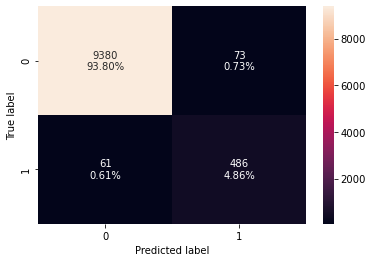

```python
# creating confusion matrix
confusion_matrix_sklearn(xgb_tuned1, X_val, y_val)
```

### Randomised Search

```python
#The model has very low precision score (however low precision shouldn't affect us much here)
#RandomizedSearchCV
#%%time

# defining model
xg_model_r = XGBClassifier(random_state=1,eval_metric='logloss')

# Parameter grid to pass in RandomizedSearchCV
param_grid={'n_estimators':np.arange(150,300,50),
            'scale_pos_weight':[5,10],
            'learning_rate':[0.1,0.2],
            'gamma':[0,3,5],
            'subsample':[0.8,0.9],}

# Type of scoring used to compare parameter combinations
scorer = metrics.make_scorer(Minimum_Vs_Model_cost, greater_is_better=True)

#Calling RandomizedSearchCV
xgb_tuned2 = RandomizedSearchCV(estimator=xg_model_r, param_distributions=param_grid, n_iter=20, scoring=scorer, cv=5, random_state=1, n_jobs = -1)

#Fitting parameters in RandomizedSearchCV
xgb_tuned2.fit(X_train_over, y_train_over)

print("Best parameters are {} with CV score={}:" .format(xgb_tuned2.best_params_,xgb_tuned2.best_score_))
```

```
Best parameters are {'subsample': 0.9, 'scale_pos_weight': 10, 'n_estimators': 200, 'learning_rate': 0.2, 'gamma': 0} with CV score=0.9876974544116328:
```

```python
# building model with best parameters
xgb_tuned2 = XGBClassifier(
    random_state=1,
    subsample= 0.9, scale_pos_weight= 10, n_estimators= 200, learning_rate= 0.2, gamma= 0
)
# Fit the model on training data
xgb_tuned2.fit(X_train_over, y_train_over)
```

[output not shown]

```
XGBClassifier(base_score=0.5, booster='gbtree', colsample_bylevel=1,
              colsample_bynode=1, colsample_bytree=1, enable_categorical=False,
              gamma=0, gpu_id=-1, importance_type=None,
              interaction_constraints='', learning_rate=0.2, max_delta_step=0,
              max_depth=6, min_child_weight=1, missing=nan,
              monotone_constraints='()', n_estimators=200, n_jobs=4,
              num_parallel_tree=1, predictor='auto', random_state=1,
              reg_alpha=0, reg_lambda=1, scale_pos_weight=10, subsample=0.9,
              tree_method='exact', validate_parameters=1, verbosity=None)
```

```python
# Calculating different metrics on train set
xgboost_random_train = model_performance_classification_sklearn(
    xgb_tuned2, X_train_over, y_train_over
)
print("Training performance:")
xgboost_random_train
```

```
Training performance:
```

|  | Accuracy | Recall | Precision | F1 | Minimum_Vs_Model_cost |
| --- | --- | --- | --- | --- | --- |
| 0 | 0.999 | 1.000 | 0.999 | 0.999 | 1.000 |

```python
# Calculating different metrics on validation set
xgboost_random_val = model_performance_classification_sklearn(xgb_tuned2, X_val, y_val)
print("Validation performance:")
xgboost_random_val
```

```
Validation performance:
```

|  | Accuracy | Recall | Precision | F1 | Minimum_Vs_Model_cost |
| --- | --- | --- | --- | --- | --- |
| 0 | 0.985 | 0.887 | 0.841 | 0.863 | 0.803 |

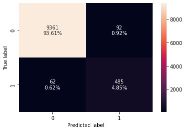

```python
# creating confusion matrix
confusion_matrix_sklearn(xgb_tuned2, X_val, y_val)
```

### Grid Search cv

```python
#defining model
model_rf = RandomForestClassifier(random_state=1)

#Parameter grid to pass in GridSearchCV
param_grid={ "n_estimators": [150,250], "min_samples_leaf": np.arange(1, 3),
            "max_features": ['sqrt','log2'],
            "max_samples": np.arange(0.2, 0.6, 0.1)}


# Type of scoring used to compare parameter combinations
scorer = metrics.make_scorer(Minimum_Vs_Model_cost, greater_is_better=True)

#Calling GridSearchCV
rf_grid_cv = GridSearchCV(estimator=model_rf, param_grid=param_grid, scoring=scorer, cv=5, n_jobs = -1, verbose= 2)

#Fitting parameters in GridSearchCV
rf_grid_cv.fit(X_train_over, y_train_over)


print("Best parameters are {} with CV score={}:" .format(rf_grid_cv.best_params_,rf_grid_cv.best_score_))
```

```
Fitting 5 folds for each of 32 candidates, totalling 160 fits
Best parameters are {'max_features': 'sqrt', 'max_samples': 0.5000000000000001, 'min_samples_leaf': 1, 'n_estimators': 250} with CV score=0.9588968858404104:
```

### Building the model with best parameters

```python
# building model with best parameters
rf_tuned1 = RandomForestClassifier(
    random_state=1,
    n_estimators=250,
    max_features= 'sqrt', max_samples= 0.5000000000000001,
    min_samples_leaf= 1,
)

# Fit the model on training data
rf_tuned1.fit(X_train_over, y_train_over)
```

```
RandomForestClassifier(max_features='sqrt', max_samples=0.5000000000000001,
                       n_estimators=250, random_state=1)
```

```python
# Calculating different metrics on train set
rf_grid_train = model_performance_classification_sklearn(
    rf_tuned1, X_train_over, y_train_over
)
print("Training performance:")
rf_grid_train
```

```
Training performance:
```

|  | Accuracy | Recall | Precision | F1 | Minimum_Vs_Model_cost |
| --- | --- | --- | --- | --- | --- |
| 0 | 0.999 | 0.998 | 1.000 | 0.999 | 0.997 |

```python
# Calculating different metrics on validation set
rf_grid_val = model_performance_classification_sklearn(rf_tuned1, X_val, y_val)
print("Validation performance:")
rf_grid_val
```

```
Validation performance:
```

|  | Accuracy | Recall | Precision | F1 | Minimum_Vs_Model_cost |
| --- | --- | --- | --- | --- | --- |
| 0 | 0.991 | 0.872 | 0.950 | 0.909 | 0.814 |

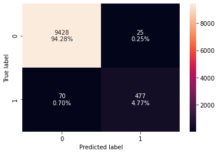

```python
# creating confusion matrix
confusion_matrix_sklearn(rf_tuned1, X_val, y_val)
```

### Randomised Search

```python
#The model has very low precision score (however low precision shouldn't affect us much here)
#RandomizedSearchCV
#%%time

# defining model
model_rf_r = RandomForestClassifier(random_state=1)

# Parameter grid to pass in RandomizedSearchCV
param_grid={ "n_estimators": [150,250], "min_samples_leaf": np.arange(1, 3),
            "max_features": ['sqrt','log2'],
            "max_samples": np.arange(0.2, 0.6, 0.1)}

# Type of scoring used to compare parameter combinations
scorer =metrics.make_scorer(Minimum_Vs_Model_cost, greater_is_better=True)

#Calling RandomizedSearchCV
rf_r = RandomizedSearchCV(estimator=model_rf_r, param_distributions=param_grid, n_iter=20, scoring=scorer, cv=5, random_state=1, n_jobs = -1)

#Fitting parameters in RandomizedSearchCV
rf_r.fit(X_train_over, y_train_over)

print("Best parameters are {} with CV score={}:" .format(rf_r.best_params_,rf_r.best_score_))
```

```
Best parameters are {'n_estimators': 250, 'min_samples_leaf': 1, 'max_samples': 0.5000000000000001, 'max_features': 'sqrt'} with CV score=0.9588968858404104:
```

```python
# building model with best parameters
rf_tuned2 = RandomForestClassifier(
    random_state=1,
    n_estimators=250,
    min_samples_leaf= 1,
    max_samples= 0.5000000000000001, max_features= 'sqrt'
)
# Fit the model on training data
rf_tuned2.fit(X_train_over, y_train_over)
```

```
RandomForestClassifier(max_features='sqrt', max_samples=0.5000000000000001,
                       n_estimators=250, random_state=1)
```

```python
# Calculating different metrics on train set
rf_random_train = model_performance_classification_sklearn(
    rf_tuned2,X_train_over, y_train_over
)
print("Training performance:")
rf_random_train
```

```
Training performance:
```

|  | Accuracy | Recall | Precision | F1 | Minimum_Vs_Model_cost |
| --- | --- | --- | --- | --- | --- |
| 0 | 0.999 | 0.998 | 1.000 | 0.999 | 0.997 |

```python
# Calculating different metrics on validation set
rf_random_val = model_performance_classification_sklearn(rf_tuned2, X_val, y_val)
print("Validation performance:")
rf_random_val
```

```
Validation performance:
```

|  | Accuracy | Recall | Precision | F1 | Minimum_Vs_Model_cost |
| --- | --- | --- | --- | --- | --- |
| 0 | 0.991 | 0.872 | 0.950 | 0.909 | 0.814 |

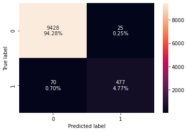

```python
# creating confusion matrix
confusion_matrix_sklearn(rf_tuned2, X_val, y_val)
```

## Bagging Classifier

### Grid Search cv

```python
#defining model
model_bc = BaggingClassifier(random_state=1)

#Parameter grid to pass in GridSearchCV
param_grid={  'max_samples': [0.8,0.9], 'max_features': [0.8,0.9], 'n_estimators' : [40,50]}


# Type of scoring used to compare parameter combinations
scorer = metrics.make_scorer(Minimum_Vs_Model_cost, greater_is_better=True)

#Calling GridSearchCV
bc_grid_cv = GridSearchCV(estimator=model_bc, param_grid=param_grid, scoring=scorer, cv=5, n_jobs = -1, verbose= 2)

#Fitting parameters in GridSearchCV
bc_grid_cv.fit(X_train_over, y_train_over)


print("Best parameters are {} with CV score={}:" .format(bc_grid_cv.best_params_,bc_grid_cv.best_score_))
```

```
Fitting 5 folds for each of 8 candidates, totalling 40 fits
Best parameters are {'max_features': 0.9, 'max_samples': 0.9, 'n_estimators': 50} with CV score=0.9643813640959931:
```

```python
# building model with best parameters
bc_tuned1 = BaggingClassifier(
    random_state=1,
  max_samples= 0.9, max_features= 0.9, n_estimators= 50
)

# Fit the model on training data
bc_tuned1.fit(X_train_over, y_train_over)
```

```
BaggingClassifier(max_features=0.9, max_samples=0.9, n_estimators=50,
                  random_state=1)
```

```python
# Calculating different metrics on train set
bc_grid_train = model_performance_classification_sklearn(
    bc_tuned1, X_train_over, y_train_over
)
print("Training performance:")
bc_grid_train
```

```
Training performance:
```

|  | Accuracy | Recall | Precision | F1 | Minimum_Vs_Model_cost |
| --- | --- | --- | --- | --- | --- |
| 0 | 1.000 | 1.000 | 1.000 | 1.000 | 1.000 |

```python
# Calculating different metrics on validation set
bc_grid_val = model_performance_classification_sklearn(bc_tuned1, X_val, y_val)
print("Validation performance:")
bc_grid_val
```

```
Validation performance:
```

|  | Accuracy | Recall | Precision | F1 | Minimum_Vs_Model_cost |
| --- | --- | --- | --- | --- | --- |
| 0 | 0.986 | 0.848 | 0.884 | 0.866 | 0.775 |

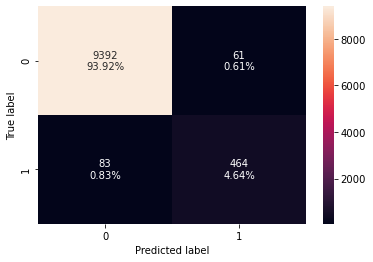

```python
# creating confusion matrix
confusion_matrix_sklearn(bc_tuned1, X_val, y_val)
```

## Randomised Search

```python
#The model has very low precision score (however low precision shouldn't affect us much here)
#RandomizedSearchCV
#%%time

# defining model
model_bc_r = BaggingClassifier(random_state=1)

# Parameter grid to pass in RandomizedSearchCV
param_grid={ 'max_samples': [0.8,0.9], 'max_features': [0.8,0.9], 'n_estimators' : [40,50]}

# Type of scoring used to compare parameter combinations
scorer =metrics.make_scorer(Minimum_Vs_Model_cost, greater_is_better=True)

#Calling RandomizedSearchCV
bc_r = RandomizedSearchCV(estimator=model_bc_r, param_distributions=param_grid, n_iter=20, scoring=scorer, cv=5, random_state=1, n_jobs = -1)

#Fitting parameters in RandomizedSearchCV
bc_r.fit(X_train_over, y_train_over)

print("Best parameters are {} with CV score={}:" .format(bc_r.best_params_,bc_r.best_score_))
```

```
Best parameters are {'n_estimators': 50, 'max_samples': 0.9, 'max_features': 0.9} with CV score=0.9643813640959931:
```

```python
# building model with best parameters
bc_tuned2 = BaggingClassifier(
    random_state=1,
   max_samples=0.9, max_features=0.9, n_estimators=50
)
# Fit the model on training data
bc_tuned2.fit(X_train_over, y_train_over)
```

```
BaggingClassifier(max_features=0.9, max_samples=0.9, n_estimators=50,
                  random_state=1)
```

```python
# Calculating different metrics on train set
bc_random_train = model_performance_classification_sklearn(
    bc_tuned2,X_train_over, y_train_over
)
print("Training performance:")
bc_random_train
```

```
Training performance:
```

|  | Accuracy | Recall | Precision | F1 | Minimum_Vs_Model_cost |
| --- | --- | --- | --- | --- | --- |
| 0 | 1.000 | 1.000 | 1.000 | 1.000 | 1.000 |

```python
# Calculating different metrics on validation set
bc_random_val = model_performance_classification_sklearn(bc_tuned2, X_val, y_val)
print("Validation performance:")
bc_random_val
```

```
Validation performance:
```

|  | Accuracy | Recall | Precision | F1 | Minimum_Vs_Model_cost |
| --- | --- | --- | --- | --- | --- |
| 0 | 0.986 | 0.848 | 0.884 | 0.866 | 0.775 |

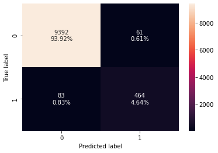

```python
# creating confusion matrix
confusion_matrix_sklearn(bc_tuned2, X_val, y_val)
```

## Model Performance comparison and choosing the final model

```python
# training performance comparison

models_train_comp_df = pd.concat(
    [    xgboost_grid_train.T,
        xgboost_random_train.T,

     rf_grid_train.T,
     rf_random_train.T,

        bc_grid_train.T,
        bc_random_train.T,


    ],
    axis=1,
)
models_train_comp_df.columns = [
   "Xgboost Tuned with Grid search",
    "Xgboost Tuned with Random Search",
    "Random Forest Tuned with Grid search",
    "Random Forest Tuned with Random search",
      "Bagging Classifier Tuned with Grid search",
    "Bagging Classifier  Tuned with Random search"]
print("Training set performance comparison:")
models_train_comp_df
```

```
Training set performance comparison:
```

|  | Xgboost Tuned with Grid search | Xgboost Tuned with Random Search | Random Forest Tuned with Grid search | Random Forest Tuned with Random search | Bagging Classifier Tuned with Grid search | Bagging Classifier Tuned with Random search |
| --- | --- | --- | --- | --- | --- | --- |
| Accuracy | 1.000 | 0.999 | 0.999 | 0.999 | 1.000 | 1.000 |
| Recall | 1.000 | 1.000 | 0.998 | 0.998 | 1.000 | 1.000 |
| Precision | 1.000 | 0.999 | 1.000 | 1.000 | 1.000 | 1.000 |
| F1 | 1.000 | 0.999 | 0.999 | 0.999 | 1.000 | 1.000 |
| Minimum_Vs_Model_cost | 1.000 | 1.000 | 0.997 | 0.997 | 1.000 | 1.000 |

```python
# Validation performance comparison

models_val_comp_df = pd.concat(
    [
        xgboost_grid_val.T,
        xgboost_random_val.T,
        rf_grid_val.T,
        rf_random_val.T,
        bc_grid_val.T,
        bc_random_val.T,

    ],
    axis=1,
)
models_val_comp_df.columns = [

    "Xgboost Tuned with Grid search",
    "Xgboost Tuned with Random Search",
    "Random Forest Tuned with Grid Search",
    "Random Forest Tuned with Random Search",
    "Bagging Classifier Tuned with Grid Search",
    "Bagging Classifier Tuned with Random Search"
]
print("Validation performance comparison:")
models_val_comp_df
```

```
Validation performance comparison:
```

|  | Xgboost Tuned with Grid search | Xgboost Tuned with Random Search | Random Forest Tuned with Grid Search | Random Forest Tuned with Random Search | Bagging Classifier Tuned with Grid Search | Bagging Classifier Tuned with Random Search |
| --- | --- | --- | --- | --- | --- | --- |
| Accuracy | 0.987 | 0.985 | 0.991 | 0.991 | 0.986 | 0.986 |
| Recall | 0.888 | 0.887 | 0.872 | 0.872 | 0.848 | 0.848 |
| Precision | 0.869 | 0.841 | 0.950 | 0.950 | 0.884 | 0.884 |
| F1 | 0.879 | 0.863 | 0.909 | 0.909 | 0.866 | 0.866 |
| Minimum_Vs_Model_cost | 0.813 | 0.803 | 0.814 | 0.814 | 0.775 | 0.775 |

- Both XGBoost tuned and Random Forest tuned are giving generalised performance.
- XGBoost grid: 0.813, XGBoost random: 0.803,
- Random Forest grid: 0.814, Random Forest Random: 0.814
- I'll choose the Random Forest random search as it's execution time is comparatively less and it is giving a slightly better performance than XGBoost

## Test set final performance

```python
# Calculating different metrics on the test set
rf_grid_test = model_performance_classification_sklearn(rf_tuned2, X_test, y_test)
print("Test performance:")
rf_grid_test
```

```
Test performance:
```

|  | Accuracy | Recall | Precision | F1 | Minimum_Vs_Model_cost |
| --- | --- | --- | --- | --- | --- |
| 0 | 0.990 | 0.857 | 0.951 | 0.902 | 0.799 |

- The performance on test data is generalised: Minimum_Vs_Model_cost = 0.799

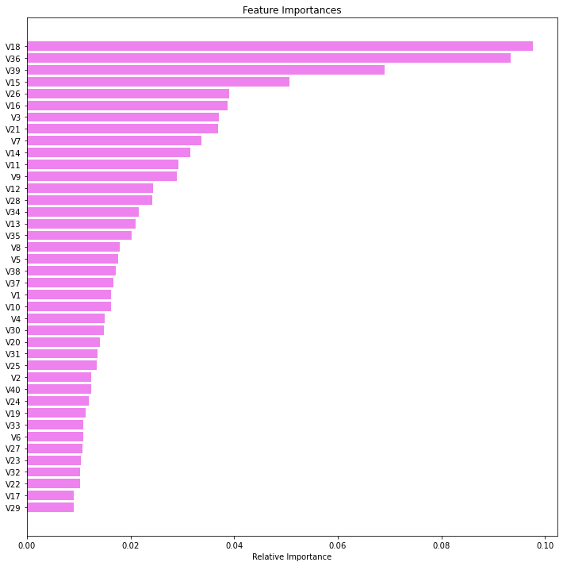

```python
feature_names = X_train.columns
importances = rf_tuned2.feature_importances_
indices = np.argsort(importances)

plt.figure(figsize=(12, 12))
plt.title("Feature Importances")
plt.barh(range(len(indices)), importances[indices], color="violet", align="center")
plt.yticks(range(len(indices)), [feature_names[i] for i in indices])
plt.xlabel("Relative Importance")
plt.show()
```

- The 10 most important features out of 40 are V18, V36, V39, V15, V26, V16, V3, V21, V7 and V14.

## Pipelines to build the final model

- We know that we can use pipelines to standardize the model building, but the steps in a pipeline are applied to each and every variable
- We will create 1 pipeline, as all the features have numeric float values.
- For numerical columns, we will do missing value imputation as pre-processing

```python
#creating a list of numerical variables
numerical_features = [
 'V1', 'V2', 'V3', 'V4', 'V5', 'V6', 'V7', 'V8', 'V9', 'V10', 'V11',
       'V12', 'V13', 'V14', 'V15', 'V16', 'V17', 'V18', 'V19', 'V20', 'V21',
       'V22', 'V23', 'V24', 'V25', 'V26', 'V27', 'V28', 'V29', 'V30', 'V31',
       'V32', 'V33', 'V34', 'V35', 'V36', 'V37', 'V38', 'V39', 'V40'
]

# creating a transformer for numerical variables, which will apply simple imputer on the numerical variables
numeric_transformer = Pipeline(steps=[("imputer", SimpleImputer(strategy="median"))])
```

```python
# Separating target variable and other variables
X1 = ren_train.drop(columns="Target")
Y1 = ren_train["Target"]
```

```python
# Separating target variable and other variables
X_test1 = ren_test.drop(columns="Target")
Y_test1 = ren_test["Target"]
```

```python
# We can't oversample data without doing missing value treatment, so let's first treat missing values in train set
imputer = SimpleImputer(strategy="median")
X1 = imputer.fit_transform(X1)
```

```python
# Synthetic Minority Over Sampling Technique
sm_t = SMOTE(sampling_strategy=1, k_neighbors=5, random_state=1)
X_over1, y_over1 = sm_t.fit_resample(X1, Y1)
```

```python
# Creating new pipeline with best parameters
model = Pipeline(
    steps=[
        ("imputer", SimpleImputer(strategy="median")),
        (
            "Random forest",
            RandomForestClassifier(
                max_features="sqrt",
                random_state=1,
                max_samples=0.5000000000000001,
                n_estimators=250,
                min_samples_leaf=1,
            ),
        ),
    ]
)
# Fit the model on training data
model.fit(X_over1, y_over1)
```

```
Pipeline(steps=[('imputer', SimpleImputer(strategy='median')),
                ('Random forest',
                 RandomForestClassifier(max_features='sqrt',
                                        max_samples=0.5000000000000001,
                                        n_estimators=250, random_state=1))])
```

```python
model.fit(X_test1, Y_test1)
```

```
Pipeline(steps=[('imputer', SimpleImputer(strategy='median')),
                ('Random forest',
                 RandomForestClassifier(max_features='sqrt',
                                        max_samples=0.5000000000000001,
                                        n_estimators=250, random_state=1))])
```

## Let's do some Analysis of False Negatives

```python
# Find out probabilities and predictions on test set
pred = model.predict(X_test1)
prob = model.predict_proba(X_test1)
```

```python
# creating a dataframe for the predicted, original and probabilities predicted by model
result = pd.DataFrame(
    np.transpose([Y_test1, pred, prob[:, 1]]),
    columns=["Original", "Predicted", "Probability"],
)
```

```python
# Let's add label of FN, FP, TP, TN based on predicted values


def Label(df):
    if (df["Predicted"] == 0) & (df["Original"] == 0):
        return "TN"

    elif (df["Predicted"] == 1) & (df["Original"] == 1):
        return "TP"

    elif df["Predicted"] > df["Original"]:
        return "FP"

    elif df["Predicted"] < df["Original"]:
        return "FN"
```

```python
result["Label"] = result.apply(Label, axis=1)
```

```python
# This is the final dataframe, which we can use to see if some pattern exists
result.head()
```

|  | Original | Predicted | Probability | Label |
| --- | --- | --- | --- | --- |
| 0 | 0.000 | 0.000 | 0.012 | TN |
| 1 | 0.000 | 0.000 | 0.012 | TN |
| 2 | 0.000 | 0.000 | 0.004 | TN |
| 3 | 0.000 | 0.000 | 0.004 | TN |
| 4 | 0.000 | 0.000 | 0.000 | TN |

```python
# With the threshold being 0.50, there could be some point near to the threshold which could be misclassified by the model
# but they could be later analyzed by the team to decide if we can take a call on those samples

result[(result["Probability"] > 0.45) & (result["Probability"] < 0.5)][
    "Label"
].value_counts()
```

```
FN    19
TN     1
Name: Label, dtype: int64
```

## Let's do some EDA for important variables

```python
### Function to plot distributions


def distribution_plot_wrt_target(data, predictor, target):

    fig, axs = plt.subplots(2, 2, figsize=(12, 10))

    target_uniq = data[target].unique()

    axs[0, 0].set_title("Distribution of target for target=" + str(target_uniq[0]))
    sns.histplot(
        data=data[data[target] == target_uniq[0]],
        x=predictor,
        kde=True,
        ax=axs[0, 0],
        color="teal",
    )

    axs[0, 1].set_title("Distribution of target for target=" + str(target_uniq[1]))
    sns.histplot(
        data=data[data[target] == target_uniq[1]],
        x=predictor,
        kde=True,
        ax=axs[0, 1],
        color="orange",
    )

    axs[1, 0].set_title("Boxplot w.r.t target")
    sns.boxplot(data=data, x=target, y=predictor, ax=axs[1, 0], palette="gist_rainbow")

    axs[1, 1].set_title("Boxplot (without outliers) w.r.t target")
    sns.boxplot(
        data=data,
        x=target,
        y=predictor,
        ax=axs[1, 1],
        showfliers=False,
        palette="gist_rainbow",
    )

    plt.tight_layout()
    plt.show()
```

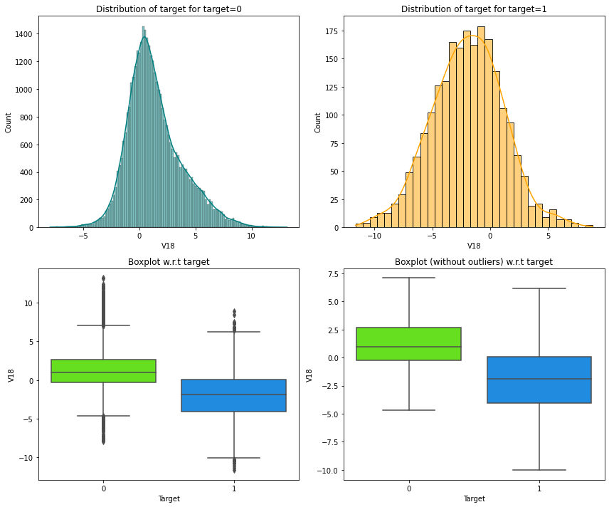

```python
distribution_plot_wrt_target(ren_train, "V18", "Target")
```

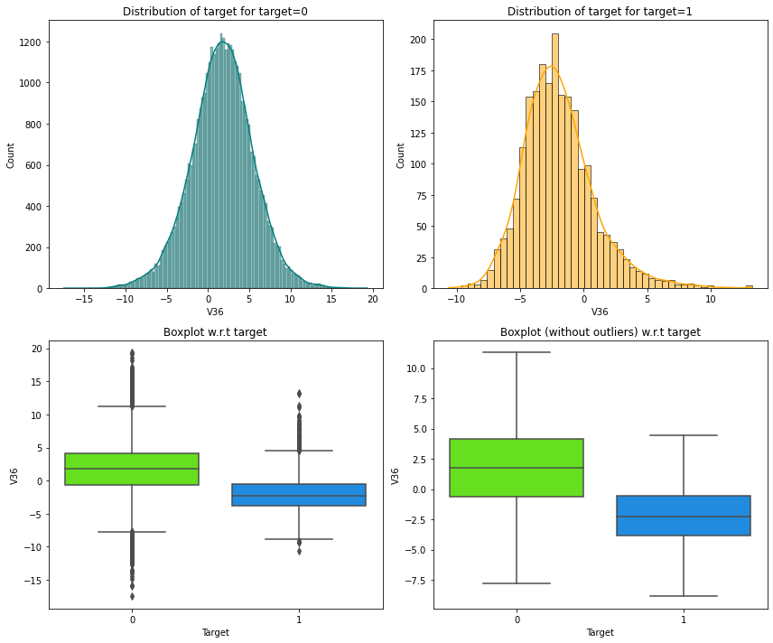

```python
distribution_plot_wrt_target(ren_train, "V36", "Target")
```

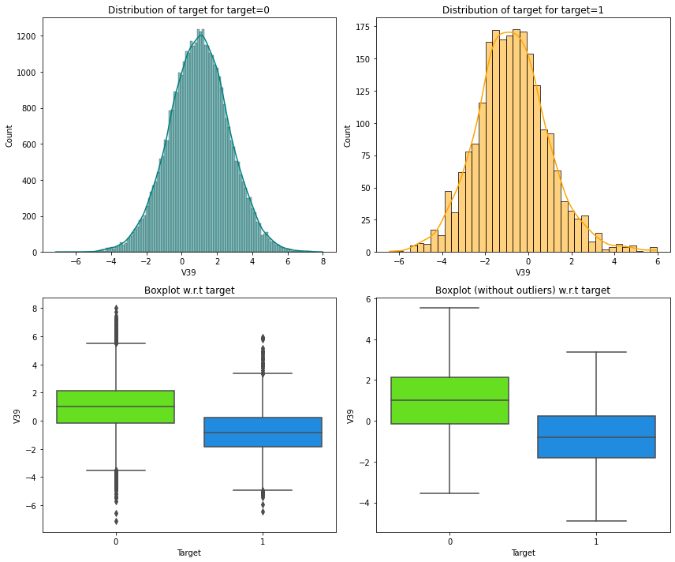

```python
distribution_plot_wrt_target(ren_train, "V39", "Target")
```

## Business Insights and Conclusions

- The 10 most important features out of 40 are V18, V36, V39, V15, V26, V16, V3, V21, V7 and V14.
- The input from these features should be considered when making predictions.
- The Random Forest tuned using oversampled data has the best performance.
- This model can be further used to detect if a wind turbine will fail or not and this will help reduce the cost.
- V18, V36 and V39 are the most important features. They can be deciphered to determine and analyze the actual variables to understand their impact on the predictive task at hand.
- We also saw that there might be few points near around the classification threshold(0.5 by default) which can be further studied by the engineer and a final call could be made.